# Cyclistic Bike Share Case Study

Peter Lawal

2023-12-23

## **Introduction**

As a junior analyst, working with the marketing analyst team with cysclistic, a bike share company based in Chicago, I have been tasked with gaining insight from company data to determine how casual and annual members use cyclistic bikes differently. From the insights gained in this analysis, the marketing team will design a new strategy to convert casual members into annual members as the director of marketing believes that the future of the company lies in converting casual members into annual members.

#### **Stakeholders**

- **Lily Moreno** - the director of marketing.
- **Cyclistic marketing analytics team** - a team of analysts responsible for collecting analyzing and reporting data that helps guide Cyclistics marketing strategy.
- **Cyclistic Executive team** - a detail oriented executive team that will decide on the approval of the recommended marketing strategy.

##### **A Short Brief About Cyclistic**

Cyclistic is a bike share company that was launched in 2016, which has since grown to a fleet of over 5,800 bicycles, geo-tracked and locked into a network of almost 700 stations across Chicago. Cyclistics marketing strategy till now has relied on building a general awareness and appealing to a broad consumer segment. one key to this strategy has been the flexibility of its pricing plans, which include full-day passes and annual memberships. Customers who purchase a full day pass are called casual riders, while those with annual memberships are called cyclistic members.  
Financial analysts at cyclistic have concluded that annual memberships are much more profitable than casual riders, thus the director of marketing has believes that there is a good chance to convert casual riders to cyclistic members.  
The marketing analyst team need to understand better how annual members and casual riders differ. The team is interested in analyzing the historical data of cyclistic to identify trends.

##### **Case Question**

*how do cyclistic members and casual riders use cyclistic differently?* what can we infer from the insights we gain in the analysis that may help the marketing team develop their strategy?

##### **Key Tasks**

- Determine how cyclistic riders are using their bikes differently
- Provide recommendations based on the analyses

##### **project methodology**

A - Ask P - Prepare P - Process A - Analyze S - Share A - Act

##### **The Dataset**

The data set used in this analysis is provided by Motivate Inc. and can be accessed here [link](https://divvy-tripdata.s3.amazonaws.com/index.html).

For this analysis, the data sets for rides taken in July, August September and October 2023 were used. The data was in CSV format, organized by columns. The data was downloaded and placed in a working folder for use. The data was sorted in Microsoft Excel by trip start time. The Data was found to be current, original and comprehensive.

The data contained Trip Ids, Start and end times for the trips, start and end stations and their station ids, Latitudes and longitudes of the start and end locations, the type of user and the type of bicycle used in the trip.

###### **Processing the Data**

Microsoft Excel was used to process the data and check it for errors and transform it so I could work with it effectively. A new column called ride_length was created and filled information calculated from subtracting the trip end time from the trip start time, and formatting the cells in time format. A new column for Day of the week that each ride started was created and filled using the Weekday function with 1 = Sunday and 7 = Saturday and formatting the column as General.

Due to the size of this data set, the files will then be imported into R to analyze the data.

##### **Working in in R**

The purpose of R in this analysis would be to help consolidate all the data into a single data frame to allow for analysis and help answer the key question “in what ways do Members and Casual riders use Cyclistic differently?”

I will go on to load the libraries that would be used for this analysis which are the `tidyverse` `lubridate`and `ggplot2` packages. * `tidyvere` for working with data * `lubridate` for working with date attributes * `ggplot` to visualize results of the analysis * `getwd` to get the working directory. * `readr` to import csv files into R

```r
library(tidyverse)
```

```r
library(lubridate)
library(ggplot2)
library(readr)
getwd()
```

```
## [1] "C:/Users/Peter Lawal/Documents"
```

###### **Importing The Data Set and Further Cleaning**

in order to be able to bring all the columns into one dataframe in R, we need to make sure the column names match using the `colnames` function

```r
colnames(august_trip_data)
```

```
##  [1] "ride_id"            "rideable_type"      "started_at"
##  [4] "ended_at"           "day_of_week"        "trip_length"
##  [7] "start_station_name" "start_station_id"   "end_station_name"
## [10] "end_station_id"     "start_lat"          "start_lng"
## [13] "end_lat"            "end_lng"            "mean_trip_length"
## [16] "max_ride_length"    "mode_day_of_week"   "member_casual"
```

```r
colnames(august_trip_data)
```

```
##  [1] "ride_id"            "rideable_type"      "started_at"
##  [4] "ended_at"           "day_of_week"        "trip_length"
##  [7] "start_station_name" "start_station_id"   "end_station_name"
## [10] "end_station_id"     "start_lat"          "start_lng"
## [13] "end_lat"            "end_lng"            "mean_trip_length"
## [16] "max_ride_length"    "mode_day_of_week"   "member_casual"
```

```r
colnames(september_trip_data)
```

```
##  [1] "ride_id"            "rideable_type"      "started_at"
##  [4] "ended_at"           "day_of_week"        "trip_length"
##  [7] "start_station_name" "start_station_id"   "end_station_name"
## [10] "end_station_id"     "start_lat"          "start_lng"
## [13] "end_lat"            "end_lng"            "mean_trip_length"
## [16] "max_trip_length"    "mode_day_of_week"   "member_casual"
```

```r
colnames(october_trip_data)
```

```
##  [1] "ride_id"            "rideable_type"      "started_at"
##  [4] "ended_at"           "trip_length"        "day_of_week"
##  [7] "start_station_name" "start_station_id"   "end_station_name"
## [10] "end_station_id"     "max_ride_length"    "mode_day_of_week"
## [13] "mean_trip_length"   "member_casual"      "X"
## [16] "X.1"                "X.2"
```

After investigating the column names, I discovered some column names did not match each other, so i proceeded to write code chunks to align the column names.

```r
july_trip_data <- rename(july_trip_data, trip_id = ride_id, mode_day_of_week = Mode_day_of_week, max_trip_length = max_ride_length, start_time = started_at, end_time = ended_at, max_trip_length = max_ride_length)
august_trip_data <- rename(august_trip_data, trip_id = ride_id, max_trip_length = max_ride_length, start_time = started_at, end_time = ended_at)
september_trip_data <- rename(september_trip_data, trip_id = ride_id, start_time = started_at, end_time = ended_at)
october_trip_data <- rename(october_trip_data, trip_id = ride_id, max_trip_length = max_ride_length, mean_trip_length = mean_trip_length, start_time = started_at, end_time = ended_at)
```

I investigated the data further using the structure function to to identify the formatting of the columns and make sure that they are aligned using the `str` function

```r
str(july_trip_data)
```

```
## 'data.frame':    767437 obs. of  18 variables:
##  $ trip_id           : chr  "D5B97E091F7E773D" "CC3C6CE0620492A6" "050060710066CF85" "3FF6C8072BDBACEB" ...
##  $ rideable_type     : chr  "classic_bike" "classic_bike" "classic_bike" "electric_bike" ...
##  $ start_time        : chr  "01/07/2023 00:00" "01/07/2023 00:00" "01/07/2023 00:00" "01/07/2023 00:00" ...
##  $ end_time          : chr  "01/07/2023 00:10" "01/07/2023 00:25" "01/07/2023 00:04" "01/07/2023 00:01" ...
##  $ trip_length       : chr  "00:10:09" "00:25:22" "00:04:28" "00:01:17" ...
##  $ day_of_week       : int  7 7 7 7 7 7 7 7 7 7 ...
##  $ start_station_name: chr  "Sangamon St & Lake St" "Canal St & Monroe St" "Sheffield Ave & Webster Ave" "" ...
##  $ start_station_id  : chr  "TA1306000015" "13056" "TA1309000033" "" ...
##  $ end_station_name  : chr  "Wood St & Chicago Ave" "Wells St & Elm St" "Lincoln Ave & Fullerton Ave" "State St & Harrison St" ...
##  $ end_station_id    : chr  "637" "KA1504000135" "TA1309000058" "SL-007" ...
##  $ start_lat         : num  41.9 41.9 41.9 41.9 41.9 ...
##  $ start_lng         : num  -87.7 -87.6 -87.7 -87.6 -87.6 ...
##  $ end_lat           : num  41.9 41.9 41.9 41.9 41.9 ...
##  $ end_lng           : num  -87.7 -87.6 -87.6 -87.6 -87.6 ...
##  $ member_casual     : chr  "casual" "casual" "member" "member" ...
##  $ mean_trip_length  : chr  "00:21:45" "00:21:45" "00:21:45" "00:21:45" ...
##  $ max_trip_length   : chr  "17:41:24" "17:41:24" "17:41:24" "17:41:24" ...
##  $ mode_day_of_week  : int  7 7 7 7 7 7 7 7 7 7 ...
```

```r
str(august_trip_data)
```

```
## 'data.frame':    771496 obs. of  18 variables:
##  $ trip_id           : chr  "E1212DA176FD5BAF" "4F9E4987AC3DF9D1" "27441012AD09BF4C" "608E6D41D97C3D3A" ...
##  $ rideable_type     : chr  "electric_bike" "classic_bike" "electric_bike" "classic_bike" ...
##  $ start_time        : chr  "01/08/2023 00:00" "01/08/2023 00:00" "01/08/2023 00:00" "01/08/2023 00:00" ...
##  $ end_time          : chr  "01/08/2023 00:02" "01/08/2023 00:01" "01/08/2023 00:05" "01/08/2023 00:11" ...
##  $ day_of_week       : int  3 3 3 3 3 3 3 3 3 3 ...
##  $ trip_length       : chr  "00:02:32" "00:00:56" "00:05:06" "00:10:32" ...
##  $ start_station_name: chr  "" "Marshfield Ave & 59th St" "St. Clair St & Erie St" "Clark St & Armitage Ave" ...
##  $ start_station_id  : chr  "" "560" "13016" "13146" ...
##  $ end_station_name  : chr  "" "Marshfield Ave & 59th St" "Franklin St & Illinois St" "Broadway & Barry Ave" ...
##  $ end_station_id    : chr  "" "560" "RN-" "13137" ...
##  $ start_lat         : num  41.9 41.8 41.9 41.9 41.9 ...
##  $ start_lng         : num  -87.7 -87.7 -87.6 -87.6 -87.7 ...
##  $ end_lat           : num  41.9 41.8 41.9 41.9 41.9 ...
##  $ end_lng           : num  -87.7 -87.7 -87.6 -87.6 -87.7 ...
##  $ mean_trip_length  : chr  "03:30:54" "03:30:54" "03:30:54" "03:30:54" ...
##  $ max_trip_length   : chr  "09:29:04" "09:29:04" "09:29:04" "09:29:04" ...
##  $ mode_day_of_week  : int  4 4 4 4 4 4 4 4 4 4 ...
##  $ member_casual     : chr  "casual" "member" "casual" "member" ...
```

```r
str(september_trip_data)
```

```
## 'data.frame':    666151 obs. of  18 variables:
##  $ trip_id           : chr  "011C1903BF4E2E28" "87DB80E048A1BF9F" "7C2EB7AF669066E3" "57D197B010269CE3" ...
##  $ rideable_type     : chr  "classic_bike" "classic_bike" "electric_bike" "classic_bike" ...
##  $ start_time        : chr  "23/09/2023 00:27" "02/09/2023 09:26" "25/09/2023 18:30" "13/09/2023 15:30" ...
##  $ end_time          : chr  "23/09/2023 00:33" "02/09/2023 09:38" "25/09/2023 18:41" "13/09/2023 15:39" ...
##  $ day_of_week       : int  7 7 2 4 2 6 4 1 1 5 ...
##  $ trip_length       : chr  "00:05:37" "00:11:36" "00:11:28" "00:08:29" ...
##  $ start_station_name: chr  "Halsted St & Wrightwood Ave" "Clark St & Drummond Pl" "Financial Pl & Ida B Wells Dr" "Clark St & Drummond Pl" ...
##  $ start_station_id  : chr  "TA1309000061" "TA1307000142" "SL-010" "TA1307000142" ...
##  $ end_station_name  : chr  "Sheffield Ave & Wellington Ave" "Racine Ave & Fullerton Ave" "Racine Ave & 15th St" "Racine Ave & Belmont Ave" ...
##  $ end_station_id    : chr  "TA1307000052" "TA1306000026" "13304" "TA1308000019" ...
##  $ start_lat         : num  41.9 41.9 41.9 41.9 41.9 ...
##  $ start_lng         : num  -87.6 -87.6 -87.6 -87.6 -87.6 ...
##  $ end_lat           : num  41.9 41.9 41.9 41.9 41.9 ...
##  $ end_lng           : num  -87.7 -87.7 -87.7 -87.7 -87.7 ...
##  $ mean_trip_length  : chr  "00:17:52" "00:17:52" "00:17:52" "00:17:52" ...
##  $ max_trip_length   : chr  "01:07:46" "01:07:46" "01:07:46" "01:07:46" ...
##  $ mode_day_of_week  : int  7 7 7 7 7 7 7 7 7 7 ...
##  $ member_casual     : chr  "member" "member" "member" "member" ...
```

```r
str(october_trip_data)
```

```
## 'data.frame':    537113 obs. of  17 variables:
##  $ trip_id           : chr  "4449097279F8BBE7" "9CF060543CA7B439" "667F21F4D6BDE69C" "F92714CC6B019B96" ...
##  $ rideable_type     : chr  "classic_bike" "electric_bike" "electric_bike" "classic_bike" ...
##  $ start_time        : chr  "08/10/2023 10:36" "11/10/2023 17:23" "12/10/2023 07:02" "24/10/2023 19:13" ...
##  $ end_time          : chr  "08/10/2023 10:49" "11/10/2023 17:36" "12/10/2023 07:06" "24/10/2023 19:18" ...
##  $ trip_length       : chr  "00:12:53" "00:12:09" "00:04:20" "00:05:26" ...
##  $ day_of_week       : int  1 4 5 3 2 4 3 2 3 3 ...
##  $ start_station_name: chr  "Orleans St & Chestnut St (NEXT Apts)" "Desplaines St & Kinzie St" "Orleans St & Chestnut St (NEXT Apts)" "Desplaines St & Kinzie St" ...
##  $ start_station_id  : chr  "620" "TA1306000003" "620" "TA1306000003" ...
##  $ end_station_name  : chr  "Sheffield Ave & Webster Ave" "Sheffield Ave & Webster Ave" "Franklin St & Lake St" "Franklin St & Lake St" ...
##  $ end_station_id    : chr  "TA1309000033" "TA1309000033" "TA1307000111" "TA1307000111" ...
##  $ max_trip_length   : chr  "00:59:57" "00:59:57" "00:59:57" "00:59:57" ...
##  $ mode_day_of_week  : int  3 3 3 3 3 3 3 3 3 3 ...
##  $ mean_trip_length  : chr  "00:15:41" "00:15:41" "00:15:41" "00:15:41" ...
##  $ member_casual     : chr  "member" "member" "member" "member" ...
##  $ X                 : logi  NA NA NA NA NA NA ...
##  $ X.1               : int  NA NA 3 NA NA NA NA NA NA NA ...
##  $ X.2               : int  NA NA NA NA NA 3 NA NA NA NA ...
```

I also discovered that the october_trip_data frame had some empty columns which i proceeded to remove using the `select` function

```r
october_trip_data <- october_trip_data %>%
  select(-c(X, X.1, X.2))
```

next, I will add the `hms` library to allow for conversion of date to time formattings.

```r
library(hms)
```

After confirming all the formatting is correct, I will then stack the datafranes into one mega data frame. I will use the bind rows function which allows us to have a longer data frame, instead of the bind col function which allows us to have a wider frame.

```r
all_trips <- bind_rows(july_trip_data, august_trip_data, september_trip_data, october_trip_data)
```

After bringing all of the trip data into a single frame, we will now proceed to remove columns we will not be using in the analysis

```r
all_trips <- all_trips %>%
  select(-c(start_lat, end_lat, start_lng, end_lng))
```

I inspect the new data frame using the code chunk below

```r
colnames(all_trips)
```

```
##  [1] "trip_id"            "rideable_type"      "start_time"
##  [4] "end_time"           "trip_length"        "day_of_week"
##  [7] "start_station_name" "start_station_id"   "end_station_name"
## [10] "end_station_id"     "member_casual"      "mean_trip_length"
## [13] "max_trip_length"    "mode_day_of_week"
```

```r
nrow(all_trips)
```

```
## [1] 2742197
```

```r
dim(all_trips)
```

```
## [1] 2742197      14
```

```r
head(all_trips)
```

```
##            trip_id rideable_type       start_time         end_time trip_length
## 1 D5B97E091F7E773D  classic_bike 01/07/2023 00:00 01/07/2023 00:10    00:10:09
## 2 CC3C6CE0620492A6  classic_bike 01/07/2023 00:00 01/07/2023 00:25    00:25:22
## 3 050060710066CF85  classic_bike 01/07/2023 00:00 01/07/2023 00:04    00:04:28
## 4 3FF6C8072BDBACEB electric_bike 01/07/2023 00:00 01/07/2023 00:01    00:01:17
## 5 D1FFA59D098F6476  classic_bike 01/07/2023 00:00 01/07/2023 00:25    00:25:29
## 6 AAAD539E3A80B743 electric_bike 01/07/2023 00:00 01/07/2023 00:07    00:07:03
##   day_of_week          start_station_name start_station_id
## 1           7       Sangamon St & Lake St     TA1306000015
## 2           7        Canal St & Monroe St            13056
## 3           7 Sheffield Ave & Webster Ave     TA1309000033
## 4           7
## 5           7        Canal St & Monroe St            13056
## 6           7    Clark St & Bryn Mawr Ave     KA1504000151
##              end_station_name end_station_id member_casual mean_trip_length
## 1       Wood St & Chicago Ave            637        casual         00:21:45
## 2           Wells St & Elm St   KA1504000135        casual         00:21:45
## 3 Lincoln Ave & Fullerton Ave   TA1309000058        member         00:21:45
## 4      State St & Harrison St         SL-007        member         00:21:45
## 5           Wells St & Elm St   KA1504000135        casual         00:21:45
## 6 Winthrop Ave & Lawrence Ave   TA1308000021        member         00:21:45
##   max_trip_length mode_day_of_week
## 1        17:41:24                7
## 2        17:41:24                7
## 3        17:41:24                7
## 4        17:41:24                7
## 5        17:41:24                7
## 6        17:41:24                7
```

```r
tail(all_trips)
```

```
##                  trip_id rideable_type       start_time         end_time
## 2742192 E264BF85F3DCCFDB electric_bike 11/10/2023 17:10 11/10/2023 17:36
## 2742193 CB82F1F5D0505469  classic_bike 30/10/2023 07:35 30/10/2023 07:49
## 2742194 E2C362589E4AD3A9  classic_bike 10/10/2023 06:29 10/10/2023 06:45
## 2742195 965D4156EDECF21A  classic_bike 26/10/2023 06:26 26/10/2023 06:39
## 2742196 0919ED32225E4D31  classic_bike 09/10/2023 08:47 09/10/2023 08:47
## 2742197 34C4F779743D5F49 electric_bike 13/10/2023 17:30 13/10/2023 17:42
##         trip_length day_of_week           start_station_name start_station_id
## 2742192    00:25:41           4 Clinton St & Washington Blvd           WL-012
## 2742193    00:13:44           2 Clinton St & Washington Blvd           WL-012
## 2742194    00:15:24           3       Clark St & Lincoln Ave            13179
## 2742195    00:13:20           5 Clinton St & Washington Blvd           WL-012
## 2742196    00:00:04           2       Michigan Ave & 14th St     TA1307000124
## 2742197    00:11:45           6 Clinton St & Washington Blvd           WL-012
##                 end_station_name end_station_id member_casual mean_trip_length
## 2742192 Fairbanks Ct & Grand Ave   TA1305000003        casual         00:15:41
## 2742193 Fairbanks Ct & Grand Ave   TA1305000003        member         00:15:41
## 2742194 Fairbanks Ct & Grand Ave   TA1305000003        member         00:15:41
## 2742195 Fairbanks Ct & Grand Ave   TA1305000003        member         00:15:41
## 2742196   Michigan Ave & 14th St   TA1307000124        member         00:15:41
## 2742197 Clark St & 9th St (AMLI)         SL-009        member         00:15:41
##         max_trip_length mode_day_of_week
## 2742192        00:59:57                3
## 2742193        00:59:57                3
## 2742194        00:59:57                3
## 2742195        00:59:57                3
## 2742196        00:59:57                3
## 2742197        00:59:57                3
```

```r
str(all_trips)
```

```
## 'data.frame':    2742197 obs. of  14 variables:
##  $ trip_id           : chr  "D5B97E091F7E773D" "CC3C6CE0620492A6" "050060710066CF85" "3FF6C8072BDBACEB" ...
##  $ rideable_type     : chr  "classic_bike" "classic_bike" "classic_bike" "electric_bike" ...
##  $ start_time        : chr  "01/07/2023 00:00" "01/07/2023 00:00" "01/07/2023 00:00" "01/07/2023 00:00" ...
##  $ end_time          : chr  "01/07/2023 00:10" "01/07/2023 00:25" "01/07/2023 00:04" "01/07/2023 00:01" ...
##  $ trip_length       : chr  "00:10:09" "00:25:22" "00:04:28" "00:01:17" ...
##  $ day_of_week       : int  7 7 7 7 7 7 7 7 7 7 ...
##  $ start_station_name: chr  "Sangamon St & Lake St" "Canal St & Monroe St" "Sheffield Ave & Webster Ave" "" ...
##  $ start_station_id  : chr  "TA1306000015" "13056" "TA1309000033" "" ...
##  $ end_station_name  : chr  "Wood St & Chicago Ave" "Wells St & Elm St" "Lincoln Ave & Fullerton Ave" "State St & Harrison St" ...
##  $ end_station_id    : chr  "637" "KA1504000135" "TA1309000058" "SL-007" ...
##  $ member_casual     : chr  "casual" "casual" "member" "member" ...
##  $ mean_trip_length  : chr  "00:21:45" "00:21:45" "00:21:45" "00:21:45" ...
##  $ max_trip_length   : chr  "17:41:24" "17:41:24" "17:41:24" "17:41:24" ...
##  $ mode_day_of_week  : int  7 7 7 7 7 7 7 7 7 7 ...
```

In the new data frame, there are 14 columns, and 2,742,197 rows and the last data point recorded for any trip was on the 30th of October, 2023, thus I can conclude that the data covers the period for the analysis.

The `summary`function would be used to give a statistical summary of all the numeric data in the data set.

```r
summary(all_trips)
```

```
##    trip_id          rideable_type       start_time          end_time
##  Length:2742197     Length:2742197     Length:2742197     Length:2742197
##  Class :character   Class :character   Class :character   Class :character
##  Mode  :character   Mode  :character   Mode  :character   Mode  :character
##
##
##
##  trip_length         day_of_week    start_station_name start_station_id
##  Length:2742197     Min.   :1.000   Length:2742197     Length:2742197
##  Class :character   1st Qu.:2.000   Class :character   Class :character
##  Mode  :character   Median :4.000   Mode  :character   Mode  :character
##                     Mean   :4.092
##                     3rd Qu.:6.000
##                     Max.   :7.000
##  end_station_name   end_station_id     member_casual      mean_trip_length
##  Length:2742197     Length:2742197     Length:2742197     Length:2742197
##  Class :character   Class :character   Class :character   Class :character
##  Mode  :character   Mode  :character   Mode  :character   Mode  :character
##
##
##
##  max_trip_length    mode_day_of_week
##  Length:2742197     Min.   :3.000
##  Class :character   1st Qu.:4.000
##  Mode  :character   Median :7.000
##                     Mean   :5.372
##                     3rd Qu.:7.000
##                     Max.   :7.000
```

in this case, it doesn’t really work for time format data types. the format for time related columns will be modified to allow for performing more statistical operations on the data set.

```r
table(all_trips$member_casual)
```

```
##
##  casual  member
## 1080898 1661299
```

The above function is to see the types of input on the usertype that is used in the table to make sure there are no confusion I proceeded to add columns that list the date, month, day and year of each data point

```r
all_trips$date <- as.Date(all_trips$start_time)
all_trips$month <- format(as.Date(all_trips$date), "%m")
all_trips$day <- format(as.Date(all_trips$date), "%d")
all_trips$year <- format(as.Date(all_trips$date), "%Y")
all_trips$day_of_week <- format(as.Date(all_trips$date), "%A")
```

I will then add a ride length calculation to the dataset calculated in seconds using the `difftime` function, but I will first convert the `start_time` and `end_time` to POSIXct format to allow for accurate results from the `difftime` calculation.

```r
all_trips$start_time <- dmy_hm(all_trips$start_time)
all_trips$end_time <- dmy_hm(all_trips$end_time)
```

```r
all_trips$ride_length <- difftime(all_trips$end_time,all_trips$start_time)
str(all_trips)
```

```
## 'data.frame':    2742197 obs. of  19 variables:
##  $ trip_id           : chr  "D5B97E091F7E773D" "CC3C6CE0620492A6" "050060710066CF85" "3FF6C8072BDBACEB" ...
##  $ rideable_type     : chr  "classic_bike" "classic_bike" "classic_bike" "electric_bike" ...
##  $ start_time        : POSIXct, format: "2023-07-01 00:00:00" "2023-07-01 00:00:00" ...
##  $ end_time          : POSIXct, format: "2023-07-01 00:10:00" "2023-07-01 00:25:00" ...
##  $ trip_length       : chr  "00:10:09" "00:25:22" "00:04:28" "00:01:17" ...
##  $ day_of_week       : chr  "Friday" "Friday" "Friday" "Friday" ...
##  $ start_station_name: chr  "Sangamon St & Lake St" "Canal St & Monroe St" "Sheffield Ave & Webster Ave" "" ...
##  $ start_station_id  : chr  "TA1306000015" "13056" "TA1309000033" "" ...
##  $ end_station_name  : chr  "Wood St & Chicago Ave" "Wells St & Elm St" "Lincoln Ave & Fullerton Ave" "State St & Harrison St" ...
##  $ end_station_id    : chr  "637" "KA1504000135" "TA1309000058" "SL-007" ...
##  $ member_casual     : chr  "casual" "casual" "member" "member" ...
##  $ mean_trip_length  : chr  "00:21:45" "00:21:45" "00:21:45" "00:21:45" ...
##  $ max_trip_length   : chr  "17:41:24" "17:41:24" "17:41:24" "17:41:24" ...
##  $ mode_day_of_week  : int  7 7 7 7 7 7 7 7 7 7 ...
##  $ date              : Date, format: "0001-07-20" "0001-07-20" ...
##  $ month             : chr  "07" "07" "07" "07" ...
##  $ day               : chr  "20" "20" "20" "20" ...
##  $ year              : chr  "0001" "0001" "0001" "0001" ...
##  $ ride_length       : 'difftime' num  600 1500 240 60 ...
##   ..- attr(*, "units")= chr "secs"
```

The is.factor function to check if a column contains numbers in numeric format The answer was false and a new line was added to convert the time format into numeric form, to allow for calculations

```r
is.factor(all_trips$ride_length)
```

```
## [1] FALSE
```

```r
all_trips$ride_length <- as.numeric(as.character(all_trips$ride_length))
is.numeric(all_trips$ride_length)
```

```
## [1] TRUE
```

I discovered that some recorded trips originated at HQ QR which means that the bikes were taken out for maintenance , we need to remove these data points as they can skew the data sets

```r
all_trips_v2 <- all_trips[!(all_trips$start_station_name == "HQ QR" | all_trips$ride_length<0),]
```

40 points have been removed

```r
tibble(all_trips_v2)
```

```
## # A tibble: 2,742,157 × 19
##    trip_id     rideable_type start_time          end_time            trip_length
##    <chr>       <chr>         <dttm>              <dttm>              <chr>
##  1 D5B97E091F… classic_bike  2023-07-01 00:00:00 2023-07-01 00:10:00 00:10:09
##  2 CC3C6CE062… classic_bike  2023-07-01 00:00:00 2023-07-01 00:25:00 00:25:22
##  3 0500607100… classic_bike  2023-07-01 00:00:00 2023-07-01 00:04:00 00:04:28
##  4 3FF6C8072B… electric_bike 2023-07-01 00:00:00 2023-07-01 00:01:00 00:01:17
##  5 D1FFA59D09… classic_bike  2023-07-01 00:00:00 2023-07-01 00:25:00 00:25:29
##  6 AAAD539E3A… electric_bike 2023-07-01 00:00:00 2023-07-01 00:07:00 00:07:03
##  7 BBD8056879… electric_bike 2023-07-01 00:00:00 2023-07-01 00:15:00 00:14:54
##  8 75A1C5532C… electric_bike 2023-07-01 00:00:00 2023-07-01 00:05:00 00:04:54
##  9 F43C9B1810… classic_bike  2023-07-01 00:00:00 2023-07-01 00:33:00 00:32:44
## 10 E8CA42EF5F… electric_bike 2023-07-01 00:00:00 2023-07-01 01:08:00 01:07:41
## # ℹ 2,742,147 more rows
## # ℹ 14 more variables: day_of_week <chr>, start_station_name <chr>,
## #   start_station_id <chr>, end_station_name <chr>, end_station_id <chr>,
## #   member_casual <chr>, mean_trip_length <chr>, max_trip_length <chr>,
## #   mode_day_of_week <int>, date <date>, month <chr>, day <chr>, year <chr>,
## #   ride_length <dbl>
```

at this point, the data set is relatively clean, I can now run our descriptive analysis on the data set

```r
mean(all_trips_v2$ride_length)
```

```
## [1] 1188.762
```

```r
median(all_trips_v2$ride_length)
```

```
## [1] 600
```

```r
max(all_trips_v2$ride_length)
```

```
## [1] 5909340
```

```r
min(all_trips_v2$ride_length)
```

```
## [1] 0
```

If you choose, the above chunk of code can also condensed into one line of code

```r
summary(all_trips_v2$ride_length)
```

```
##    Min. 1st Qu.  Median    Mean 3rd Qu.    Max.
##       0     360     600    1189    1080 5909340
```

###### **Aggregating by usertype and monthy mean**

I will then agregate the descriptive stats by user type The `FUN` means function

```r
aggregate(all_trips_v2$ride_length ~ all_trips_v2$member_casual, FUN = mean ) #casual = 1794.0200  member = 794.9642
```

```
##   all_trips_v2$member_casual all_trips_v2$ride_length
## 1                     casual                1794.0200
## 2                     member                 794.9642
```

```r
aggregate(all_trips_v2$ride_length ~ all_trips_v2$member_casual, FUN = median ) #casual= 780 and member = 540
```

```
##   all_trips_v2$member_casual all_trips_v2$ride_length
## 1                     casual                      780
## 2                     member                      540
```

```r
aggregate(all_trips_v2$ride_length ~ all_trips_v2$member_casual, FUN = max)  #casual = 5909,340,  member = 90,000
```

```
##   all_trips_v2$member_casual all_trips_v2$ride_length
## 1                     casual                  5909340
## 2                     member                    90000
```

```r
aggregate(all_trips_v2$ride_length ~ all_trips_v2$member_casual, FUN = min ) #casual and member = 0
```

```
##   all_trips_v2$member_casual all_trips_v2$ride_length
## 1                     casual                        0
## 2                     member                        0
```

```r
monthly_mean <- aggregate(all_trips_v2$ride_length ~ all_trips_v2$month + all_trips_v2$member_casual, FUN = mean )
 aggregate(all_trips_v2$ride_length ~ all_trips_v2$month + all_trips_v2$member_casual, FUN = mean )
```

```
##   all_trips_v2$month all_trips_v2$member_casual all_trips_v2$ride_length
## 1                 07                     casual                1940.6462
## 2                 08                     casual                2115.3771
## 3                 09                     casual                1511.6557
## 4                 10                     casual                1372.3108
## 5                 07                     member                 821.6848
## 6                 08                     member                 826.5005
## 7                 09                     member                 788.9075
## 8                 10                     member                 729.0670
```

```r
monthly_total <- aggregate(all_trips_v2$ride_length ~ all_trips_v2$month + all_trips_v2$member_casual, FUN = sum )
aggregate(all_trips_v2$ride_length ~ all_trips_v2$month + all_trips_v2$member_casual, FUN = sum )
```

```
##   all_trips_v2$month all_trips_v2$member_casual all_trips_v2$ride_length
## 1                 07                     casual                642842940
## 2                 08                     casual                657926700
## 3                 09                     casual                395349360
## 4                 10                     casual                242992320
## 5                 07                     member                358406580
## 6                 08                     member                380558040
## 7                 09                     member                319205400
## 8                 10                     member                262489620
```

The last two lines will create data freames that agregate the datasets based on the monthly means and monthly averages of the data points.

###### **Agregating by user type**

I will aggregate by day of week for each member type but first put the days of the week in order

```r
all_trips_v2$day_of_week<- ordered(all_trips_v2$day_of_week, levels=c("Sunday","Monday","Tuesday","Wednesday","Thursday","Friday","Saturday"))
```

and then aggregate

```r
aggregate(all_trips_v2$ride_length ~ all_trips_v2$member_casual+all_trips_v2$day_of_week, FUN = mean )
```

[output not shown]

from here I look at the ridership data by the type of bike used for the trips

```r
all_trips_v2 %>%
  mutate(weekday = wday(start_time, label = TRUE)) %>%  #creates a weekdayfieldusing the wday() funtion
  group_by(member_casual, weekday) %>%  #groups by usertype and weekday
  summarise(number_of_rides = n(), average_duration = mean (ride_length)) %>%  #calculates the number of rides and average duration and the mean or average ride duration
  arrange(member_casual, weekday) #sorts the results
```

```
## # A tibble: 14 × 4
## # Groups:   member_casual [2]
##    member_casual weekday number_of_rides average_duration
##    <chr>         <ord>             <int>            <dbl>
##  1 casual        Sun              188255            2071.
##  2 casual        Mon              125476            1767.
##  3 casual        Tue              133030            1617.
##  4 casual        Wed              122996            1562.
##  5 casual        Thu              131365            1597.
##  6 casual        Fri              159854            1732.
##  7 casual        Sat              219899            1972.
##  8 member        Sun              198182             889.
##  9 member        Mon              227677             753.
## 10 member        Tue              264794             765.
## 11 member        Wed              253347             759.
## 12 member        Thu              255040             758.
## 13 member        Fri              237317             799.
## 14 member        Sat              224925             867.
```

#### **Visualizing The Results**

##### **Number of Rides By Average Trip Duration, Grouped by User type**

This operation will be performed using `ggplot2`

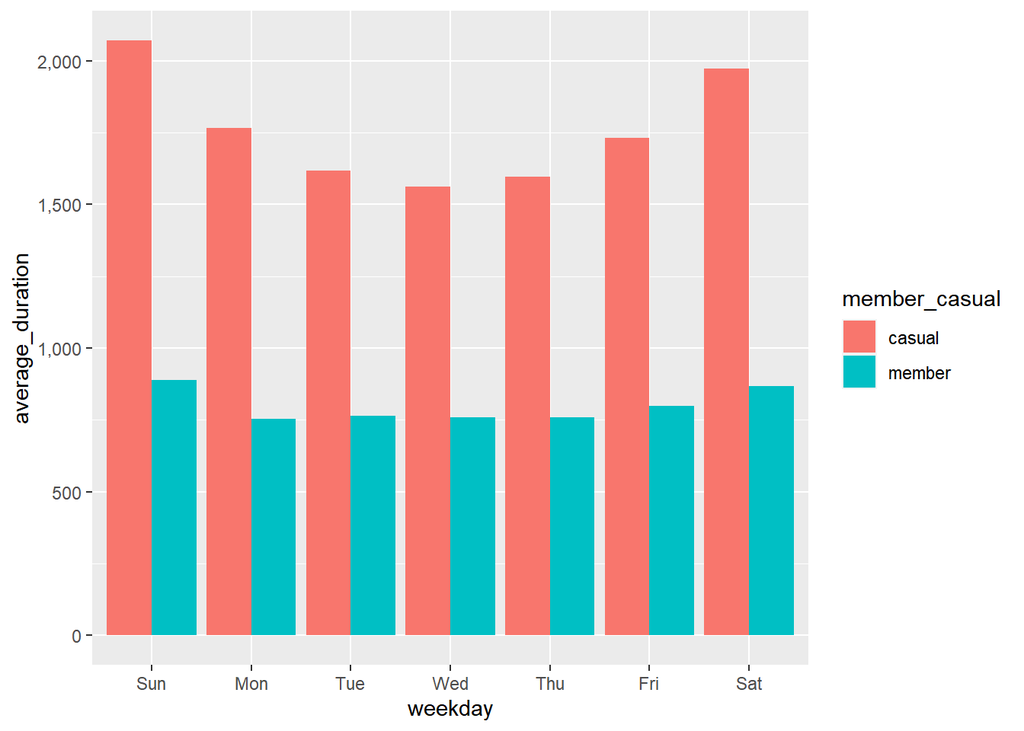

```r
all_trips_v2 %>%
  mutate(weekday = wday(start_time, label = TRUE)) %>%
  group_by(member_casual, weekday) %>%
  summarise(number_of_rides = n(), average_duration = mean (ride_length)) %>%
  arrange(member_casual, weekday) %>%
  ggplot(aes(x = weekday, y = average_duration, fill = member_casual)) +
  geom_col(position = "dodge")+
  scale_y_continuous(labels = scales::comma) #this line prevents the axis labels from rendering in  exponents
```

##### **Number of Rides Grouped by Usertype**

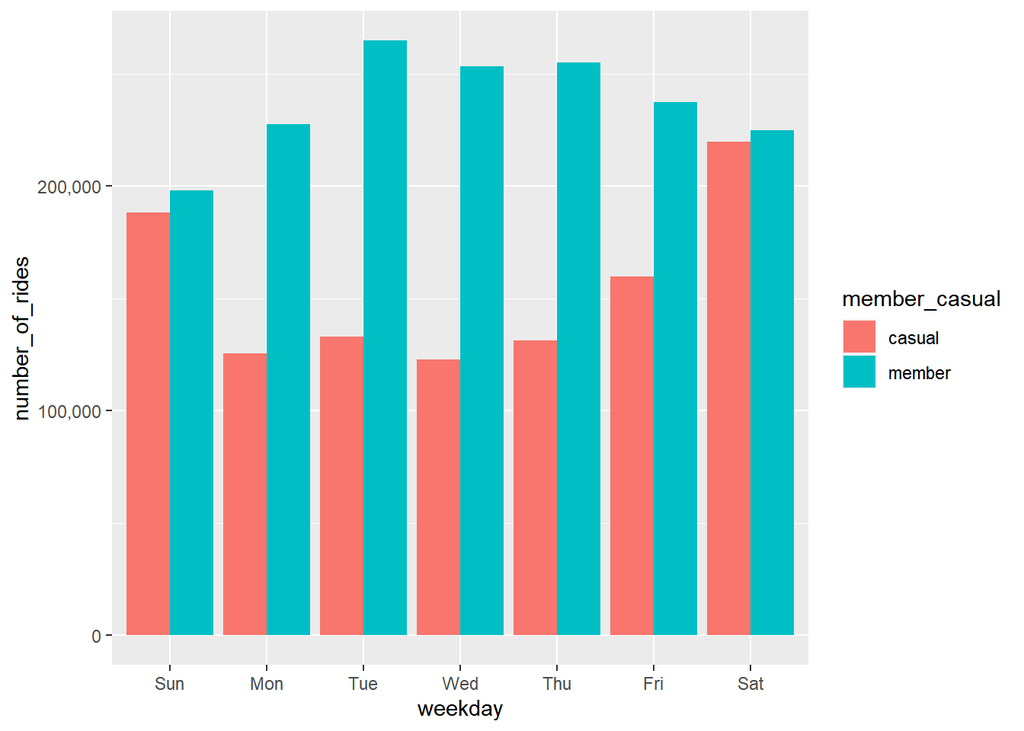

```r
all_trips_v2 %>%
  mutate(weekday = wday(start_time, label = TRUE)) %>%
  group_by(member_casual, weekday) %>%
  summarise(number_of_rides = n(), average_duration = mean (ride_length)) %>%
  arrange(member_casual, weekday) %>%
  ggplot(aes(x = weekday, y = number_of_rides, fill = member_casual)) +
  geom_col(position = "dodge") +
  scale_y_continuous(labels = scales::comma)
```

######**Other Vizzes** I will create some more data frames that could give us some more information about how users may use cyclistic differently. These frames will be created using the `aggregate` function.

I will create a rideable_counts dataframe which summarizes all trips by bicycle type and usertype

```r
aggregate(all_trips_v2$rideable_type, by = list(all_trips_v2$rideable_type, all_trips_v2$member_casual), FUN = length)
```

```
##         Group.1 Group.2      x
## 1  classic_bike  casual 506842
## 2   docked_bike  casual  34381
## 3 electric_bike  casual 539652
## 4  classic_bike  member 867902
## 5 electric_bike  member 793380
```

```r
rideable_counts <- aggregate(all_trips_v2$rideable_type, by = list(all_trips_v2$rideable_type, all_trips_v2$member_casual), FUN = length)
```

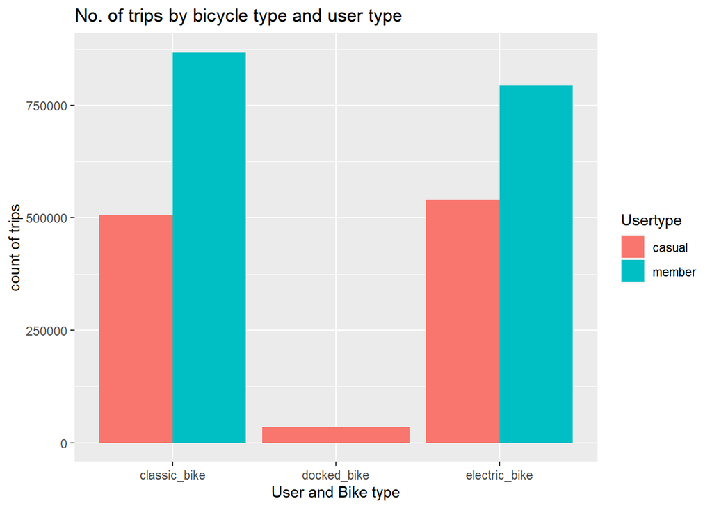

```r
aggregate(all_trips_v2$rideable_type, by = list(all_trips_v2$rideable_type, all_trips_v2$member_casual), FUN = length) %>%
  ggplot(aes(x = Group.1, y = x, fill = Group.2)) +
  geom_col(position = "dodge")+
  labs(title = "No. of trips by bicycle type and user type", x ="User and Bike type", y ="count of trips", fill = "Usertype" )
```

**Average Ride Length By Bicycle Type** a data frame of average ride length by bicycle type

```r
ave_ride_length_by_rideable <- aggregate(all_trips_v2$ride_length ~ all_trips_v2$rideable_type + all_trips_v2$member_casual, FUN = mean)
ave_ride_length_by_rideable$`all_trips_v2$ride_length` <- as.integer(as.double(ave_ride_length_by_rideable$`all_trips_v2$ride_length`)) #to allow the ave ride length to be plotted as it currently is formatted as a dbl
tibble(ave_ride_length_by_rideable)
```

```
## # A tibble: 5 × 3
##   `all_trips_v2$rideable_type` all_trips_v2$member_casu…¹ all_trips_v2$ride_le…²
##   <chr>                        <chr>                                       <int>
## 1 classic_bike                 casual                                       1979
## 2 docked_bike                  casual                                      13251
## 3 electric_bike                casual                                        889
## 4 classic_bike                 member                                        874
## 5 electric_bike                member                                        708
## # ℹ abbreviated names: ¹`all_trips_v2$member_casual`,
## #   ²`all_trips_v2$ride_length`
```

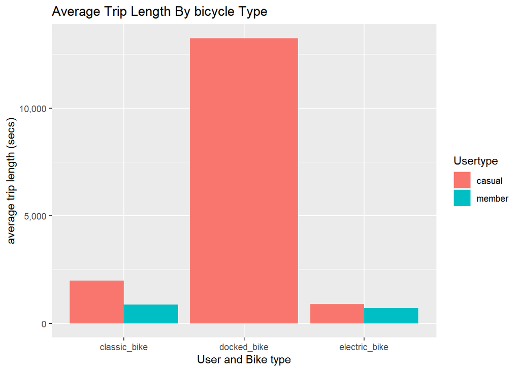

```r
ave_ride_length_by_rideable %>%
  ggplot(aes(x = `all_trips_v2$rideable_type`, y = `all_trips_v2$ride_length`, fill = `all_trips_v2$member_casual`)) +
  geom_col(position = "dodge")+
  labs(title = "Average Trip Length By bicycle Type", x ="User and Bike type", y ="average trip length (secs)", fill = "Usertype" ) +
  scale_y_continuous(labels = scales::comma)
```

**Average ride length by Day of week**

```r
 ave_ride_length_by_day_of_week <- aggregate(all_trips_v2$ride_length ~ all_trips_v2$member_casual + all_trips_v2$day_of_week, FUN = mean)
tibble(ave_ride_length_by_day_of_week)
```

[output not shown]

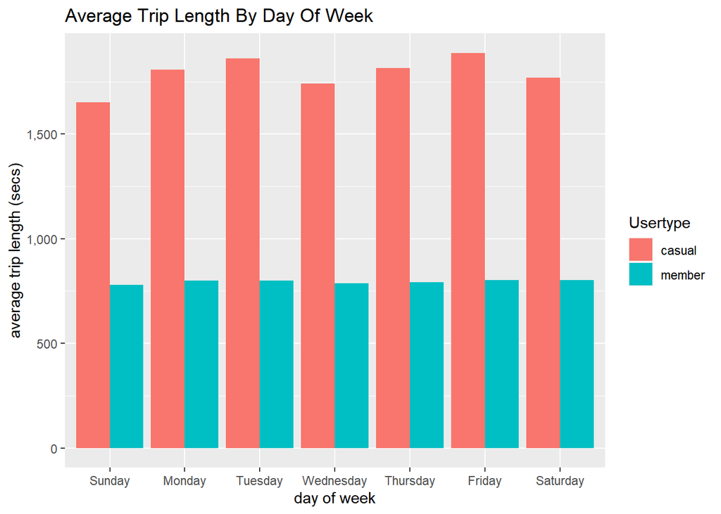

```r
ave_ride_length_by_day_of_week %>%
  ggplot(aes(x = `all_trips_v2$day_of_week`, y = `all_trips_v2$ride_length`, fill = `all_trips_v2$member_casual`)) +
  geom_col(position = "dodge")+
  labs(title = "Average Trip Length By Day Of Week", x ="day of week", y ="average trip length (secs)", fill = "Usertype" ) +
  scale_y_continuous(labels = scales::comma)
```

**Total ride length by day of week**

```r
total_ride_length_by_day <- aggregate(all_trips_v2$ride_length ~ all_trips_v2$day_of_week, FUN = sum)
total_ride_length_by_day$`all_trips_v2$ride_length` <- as.numeric(as.double(total_ride_length_by_day$`all_trips_v2$ride_length`))
tibble(total_ride_length_by_day)
```

```
## # A tibble: 7 × 2
##   `all_trips_v2$day_of_week` `all_trips_v2$ride_length`
##   <ord>                                           <dbl>
## 1 Sunday                                      434680020
## 2 Monday                                      501637260
## 3 Tuesday                                     476145120
## 4 Wednesday                                   430276500
## 5 Thursday                                    457105560
## 6 Friday                                      508005780
## 7 Saturday                                    451920720
```

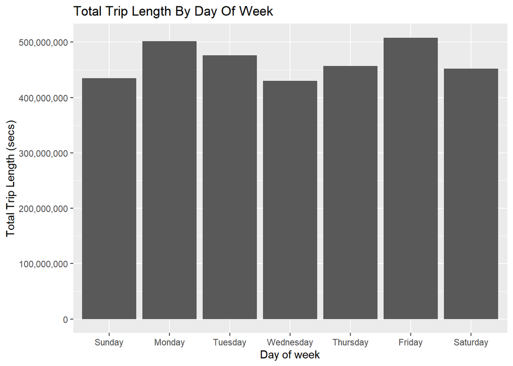

```r
total_ride_length_by_day %>%
   ggplot(aes(x = `all_trips_v2$day_of_week`, y = `all_trips_v2$ride_length`)) +
  geom_col(position = "dodge")+
  labs(title = "Total Trip Length By Day Of Week", x ="Day of week", y ="Total Trip Length (secs)") +
  scale_y_continuous(labels = scales::comma)
```

**Total ride length by month**

```r
aggregate(all_trips_v2$ride_length ~ all_trips_v2$month, FUN = sum)
```

```
##   all_trips_v2$month all_trips_v2$ride_length
## 1                 07               1001249520
## 2                 08               1038484740
## 3                 09                714554760
## 4                 10                505481940
```

```r
total_trip_length_by_month <- aggregate(all_trips_v2$ride_length ~ all_trips_v2$month, FUN = sum)
```

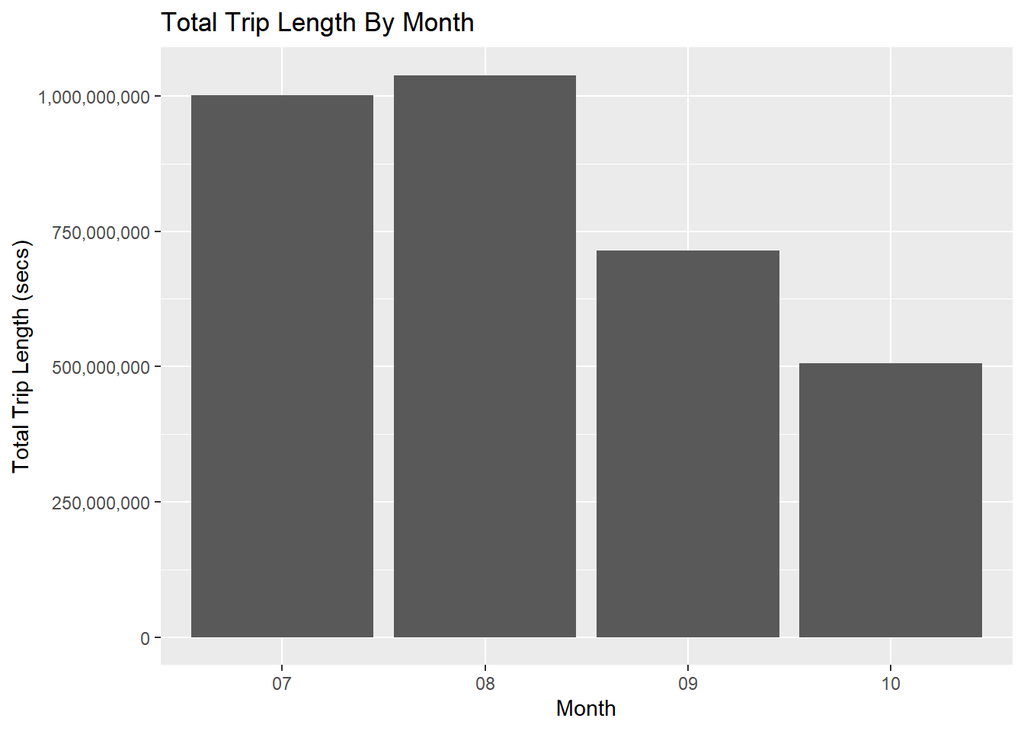

```r
total_trip_length_by_month %>%
  ggplot(aes(x = `all_trips_v2$month`, y = `all_trips_v2$ride_length`)) +
  geom_col(position = "dodge")+
  labs(title = "Total Trip Length By Month", x ="Month", y ="Total Trip Length (secs)") +
  scale_y_continuous(labels = scales::comma)
```

**Total Trip Length By Month And Usertype**

```r
aggregate(all_trips_v2$ride_length, by = list(all_trips_v2$month, all_trips_v2$member_casual), FUN = sum)
```

```
##   Group.1 Group.2         x
## 1      07  casual 642842940
## 2      08  casual 657926700
## 3      09  casual 395349360
## 4      10  casual 242992320
## 5      07  member 358406580
## 6      08  member 380558040
## 7      09  member 319205400
## 8      10  member 262489620
```

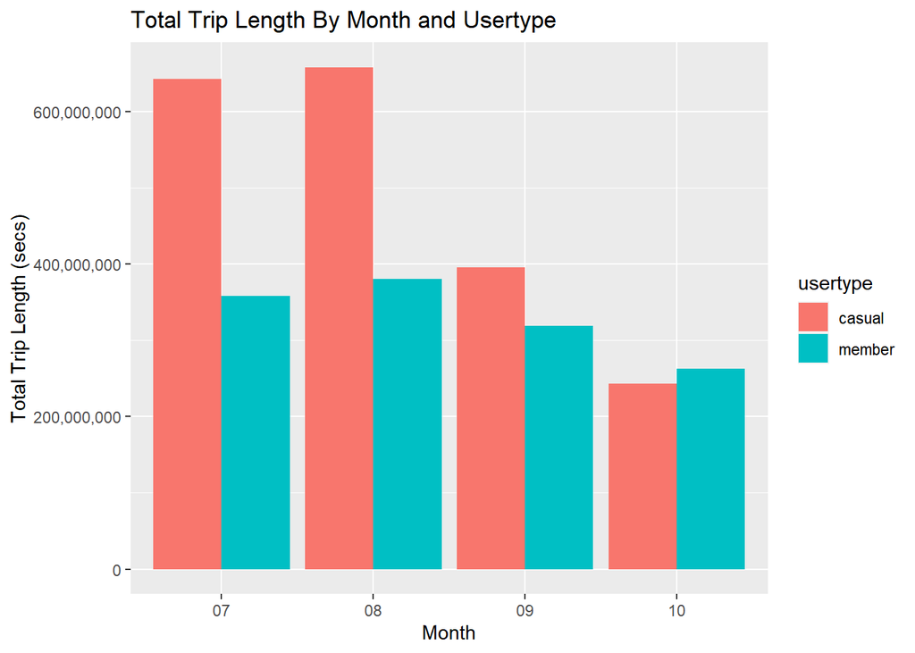

```r
total_trip_length_by_month_usertype <- aggregate(all_trips_v2$ride_length, by = list(all_trips_v2$month, all_trips_v2$member_casual), FUN = sum)
total_trip_length_by_month_usertype %>%
  ggplot(aes(x = `Group.1`, y = `x`, fill= `Group.2`)) +
  geom_col(position = "dodge")+
  labs(title = "Total Trip Length By Month and Usertype", x ="Month", y ="Total Trip Length (secs)", fill ="usertype") +
  scale_y_continuous(labels = scales::comma)
```

**Average ride length by month and usertype**

```r
aggregate(all_trips_v2$ride_length ~ all_trips_v2$month + all_trips_v2$member_casual, FUN = mean)
```

```
##   all_trips_v2$month all_trips_v2$member_casual all_trips_v2$ride_length
## 1                 07                     casual                1940.6462
## 2                 08                     casual                2115.3771
## 3                 09                     casual                1511.6557
## 4                 10                     casual                1372.3108
## 5                 07                     member                 821.6848
## 6                 08                     member                 826.5005
## 7                 09                     member                 788.9075
## 8                 10                     member                 729.0670
```

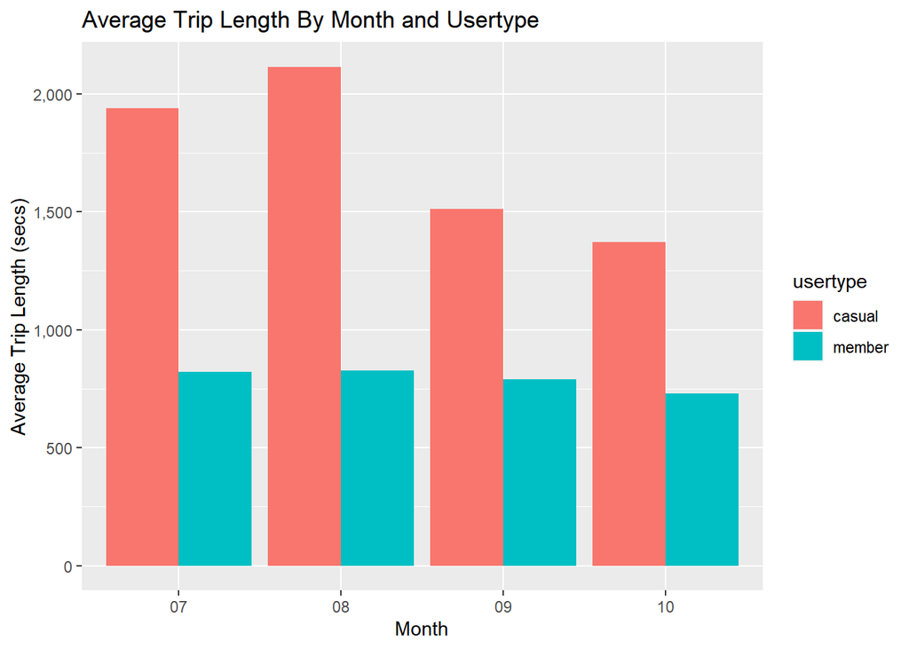

```r
average_trip_length_by_month <- aggregate(all_trips_v2$ride_length ~ all_trips_v2$month + all_trips_v2$member_casual, FUN = mean)
average_trip_length_by_month %>%
  ggplot(aes(x = `all_trips_v2$month`, y = `all_trips_v2$ride_length`, fill= `all_trips_v2$member_casual`)) +
  geom_col(position = "dodge")+
  labs(title = "Average Trip Length By Month and Usertype", x ="Month", y ="Average Trip Length (secs)", fill ="usertype") +
  scale_y_continuous(labels = scales::comma)
```

#### **Average count of trips per month**

I will finally visualize the average count of trips per month.

```r
aggregate(all_trips_v2$trip_id, by = list(all_trips_v2$month, all_trips_v2$member_casual), FUN = length)
```

```
##   Group.1 Group.2      x
## 1      07  casual 331252
## 2      08  casual 311021
## 3      09  casual 261534
## 4      10  casual 177068
## 5      07  member 436185
## 6      08  member 460445
## 7      09  member 404617
## 8      10  member 360035
```

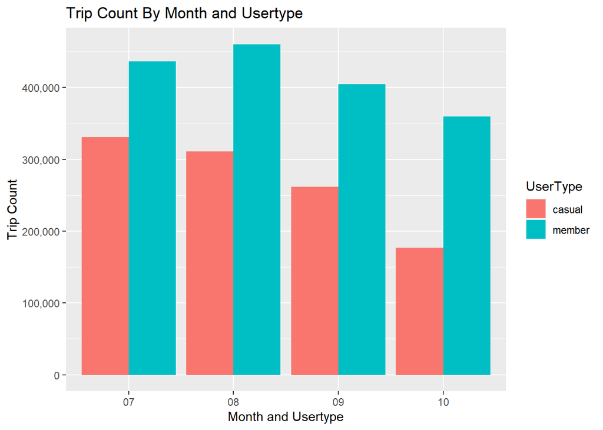

```r
aggregate(all_trips_v2$trip_id, by = list(all_trips_v2$month, all_trips_v2$member_casual), FUN = length) %>%
  ggplot(aes(x = `Group.1`, y = `x`, fill= `Group.2`)) +
  geom_col(position = "dodge")+
  labs(title = "Trip Count By Month and Usertype", x ="Month and Usertype", y ="Trip Count", fill ="UserType") +
  scale_y_continuous(labels = scales::comma)
```

#### **Results**

My observations of the data set are summarized below:

- The average trip on cyclistic lasted 1,188.762 seconds while the longest running trip which was by a casual user lasted for 5,909,340 second.
- Casual users ride for an average of 1,794.02 seconds while members ride for less, averaging 794.96 seconds.
- The longest running trip for members is 90,000 seconds.
- For the day of the week, Sundays happened to have the highest average duration of trips with Casual users averaging 2,071 seconds and members averaged 889 seconds. However, by day of the week, Members took more trips than Casual users with the highest count for members being on Tuesdays. Ride counts on the weekends for both groups seemed to mirror each other on the weekends with more cumulative trips on Saturdays and Sundays.
- By bicycle type, casual users favored the electric bike over the classic bike while members favored the classic bike over the electric bike. However, although docked bikes saw the lowest number of trips, they had the highest average trip length, averaging over 13,251 seconds, with the classic bike having the second highest average trip length for both casual users and Members. It is important to note that Docked bike were only used by casual users and were discontinued in September of 2023.
- By day of the week, Wednesdays saw the lowest total trip length while Friday had the highest.
- By month, on removal of docked bikes as an option, a sharp and continuous drop of 31.193% and and 29.26% drop in total trip length in September and Octoberwas observed.
- Total trip length by user type also dropped on a monthly basis with casual users seeing a 39.91% and 38.54% drop in trip length in September and October.

#### **Insights**

The goal of this analysis is to figure out how Cyclistic user types use cyclistic differently. After analyzing the data provided, these were my findings

- Casual users take on average, generally longer rides than Members however, members take more trips than casual members
- Total trip length, average trip length and number of trips declined month on month from August to September.
- Users tended to favor different types of bikes for their rides, with Casual users favoring electric bikes and Members favoring classic bikes
- The average trip length for user types was higher on Sundays. and weekends in general.

### **Recommendations**

- We could consider promoting benefits of Annual memberships as including shorter and more convenient trips.
- Considering that the weekends see a higher average trip lengths, special offers could be promoted on weekends to Casual users to convince them to convert to annual memberships
- We may also consider extending special offers that are member only for certain bike types especially bike types favored by Casual users that may encourage casual users to convert to annual users.
- Develop retention strategies such as Loyalty programs or incentives to keep members engaged considering the drop in monthly total and average rides.

#### **Exporting Data Frames For Visualization in an External Visualization Software**

Add the `readxl`library to allow for writing of the data frames into worksheets

```r
library(readxl)
library(openxlsx)
```

I will use the `write.xlsx` function to create an excel spreadsheet containing the data frame that has just been created.

```r
write.xlsx(average_trip_length_by_month, file="average_trip_length_by_month.xlsx", sheetName="average_trip_length_by_month", colNames=TRUE, rowNames=FALSE, append=FALSE)
write.xlsx(monthly_mean, file="monthly_mean.xlsx", sheetName="monthly_mean", colNames=TRUE, rowNames=FALSE, append=TRUE)
write.xlsx(monthly_total, file="monthly_total.xlsx", sheetName="monthly_total", colNames=TRUE, rowNames=FALSE, append=TRUE)
write.xlsx(rideable_counts, file="rideable_counts.xlsx", sheetName="rideable_counts", colNames=TRUE, rowNames=FALSE, append=TRUE)
write.xlsx(ave_ride_length_by_rideable, file="ave_ride_length_by_rideable.xlsx", sheetName="ave_ride_length_by_rideable", colNames=TRUE, rowNames=FALSE, append=TRUE)
write.xlsx(total_ride_length_by_day, file="total_ride_length_by_day.xlsx", sheetName="total_ride_length_by_day", colNames=TRUE, rowNames=FALSE, append=TRUE)
write.xlsx(total_ride_length_by_day, file="total_ride_length_by_day.xlsx", sheetName="total_ride_length_by_day", colNames=TRUE, rowNames=FALSE, append=TRUE)
write.xlsx(total_trip_length_by_month, file="total_trip_length_by_month.xlsx", sheetName="total_trip_length_by_month", colNames=TRUE, rowNames=FALSE, append=TRUE)
```

Now, I have come to the end of my analysis in R. The rest of the that has been to .xlsx files can then be visualised in Excel or tableau.